# INFO370lab04

Marco

2024-06-27

```r
library(tidyverse)
```

## 1

### 1.1

```r
temp <- read_delim("../../data/UAH-lower-troposphere-wide.csv.bz2")
dim(temp)
```

```
## [1] 546  29
```

```r
sample_n(temp, 5)
```

```
## # A tibble: 5 × 29
##    year month globe globe_land globe_ocean    nh nh_land nh_ocean    sh sh_land
##   <dbl> <dbl> <dbl>      <dbl>       <dbl> <dbl>   <dbl>    <dbl> <dbl>   <dbl>
## 1  1999     3 -0.21      -0.29       -0.18 -0.28   -0.39    -0.21 -0.14   -0.06
## 2  2023     2  0.09       0.21        0.04  0.17    0.3      0.09  0       0
## 3  2008    10 -0.16       0.03       -0.23 -0.15    0.1     -0.31 -0.17   -0.14
## 4  1998    10  0.24       0.32        0.21  0.31    0.47     0.21  0.17   -0.03
## 5  1997     7 -0.04      -0.21        0.02 -0.03   -0.15     0.05 -0.06   -0.35
## # ℹ 19 more variables: sh_ocean <dbl>, trpcs <dbl>, trpcs_land <dbl>,
## #   trpcs_ocean <dbl>, noext <dbl>, noext_land <dbl>, noext_ocean <dbl>,
## #   soext <dbl>, soext_land <dbl>, soext_ocean <dbl>, nopol <dbl>,
## #   nopol_land <dbl>, nopol_ocean <dbl>, sopol <dbl>, sopol_land <dbl>,
## #   sopol_ocean <dbl>, usa48 <dbl>, usa49 <dbl>, aust <dbl>
```

### 1.2

```r
range(temp$year)
```

```
## [1] 1978 2024
```

```r
range(temp$month)
```

```
## [1]  1 12
```

Year range from 1978 to 2024, month range from 1 to 12

### 1.3

```r
temp <- temp %>%
  mutate(time = year + month/12)

head(temp)
```

```
## # A tibble: 6 × 30
##    year month globe globe_land globe_ocean    nh nh_land nh_ocean    sh sh_land
##   <dbl> <dbl> <dbl>      <dbl>       <dbl> <dbl>   <dbl>    <dbl> <dbl>   <dbl>
## 1  1978    12 -0.48      -0.51       -0.47 -0.44   -0.47    -0.43 -0.52   -0.62
## 2  1979     1 -0.48      -0.64       -0.41 -0.64   -0.87    -0.5  -0.31   -0.13
## 3  1979     2 -0.44      -0.56       -0.39 -0.48   -0.57    -0.42 -0.4    -0.53
## 4  1979     3 -0.39      -0.52       -0.34 -0.47   -0.51    -0.44 -0.31   -0.53
## 5  1979     4 -0.41      -0.57       -0.34 -0.47   -0.62    -0.38 -0.34   -0.46
## 6  1979     5 -0.4       -0.56       -0.33 -0.53   -0.54    -0.52 -0.27   -0.62
## # ℹ 20 more variables: sh_ocean <dbl>, trpcs <dbl>, trpcs_land <dbl>,
## #   trpcs_ocean <dbl>, noext <dbl>, noext_land <dbl>, noext_ocean <dbl>,
## #   soext <dbl>, soext_land <dbl>, soext_ocean <dbl>, nopol <dbl>,
## #   nopol_land <dbl>, nopol_ocean <dbl>, sopol <dbl>, sopol_land <dbl>,
## #   sopol_ocean <dbl>, usa48 <dbl>, usa49 <dbl>, aust <dbl>, time <dbl>
```

### 1.4

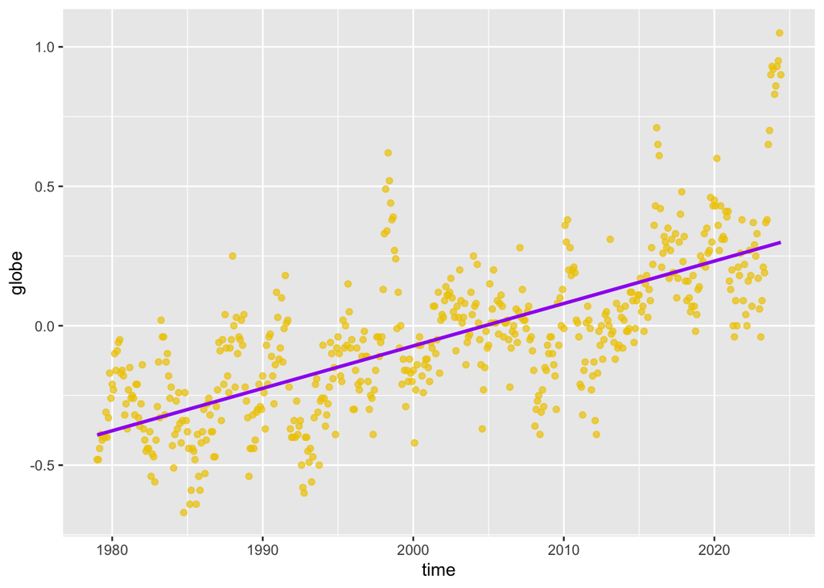

```r
temp %>%
  ggplot(aes(time, globe)) +
  geom_point(color = "gold2", alpha = 0.7) +
  geom_smooth(method = "lm", se = FALSE, color = "purple")
```

### 1.5 We are not capture the trend within year, there might be some variation between that. But we would focus on the overall trend so it is a good approximation.

### 1.6

```r
model <- lm(globe ~ time, data = temp)
summary(model)
```

```
##
## Call:
## lm(formula = globe ~ time, data = temp)
##
## Residuals:
##      Min       1Q   Median       3Q      Max
## -0.50272 -0.12135 -0.01896  0.10140  0.75224
##
## Coefficients:
##               Estimate Std. Error t value Pr(>|t|)
## (Intercept) -3.049e+01  1.287e+00  -23.70   <2e-16 ***
## time         1.521e-02  6.428e-04   23.66   <2e-16 ***
## ---
## Signif. codes:  0 '***' 0.001 '**' 0.01 '*' 0.05 '.' 0.1 ' ' 1
##
## Residual standard error: 0.1973 on 544 degrees of freedom
## Multiple R-squared:  0.5071, Adjusted R-squared:  0.5062
## F-statistic: 559.8 on 1 and 544 DF,  p-value: < 2.2e-16
```

### 1.7

The number means that as year increase time(year) by one, the global temperature deviation would increase by a mean of 0.01521. It is statistically significant at 0 confidence level.

### 1.8

Intercept means that when time 2000 years ago. The global temperature deviation has a mean of -30.48959.

### 1.9

The “GTR” (global temperature report) from University of Alabama, Huntsville also shows a overall increasing trend.

## 2

### 2.1

```r
gdp <- read_delim("../../data/gapminder.csv.bz2")
dim(gdp)
```

```
## [1] 13055    25
```

```r
sample_n(gdp, 5)
```

```
## # A tibble: 5 × 25
##   iso3  name        iso2  region   `sub-region`      `intermediate-region`  time
##   <chr> <chr>       <chr> <chr>    <chr>             <chr>                 <dbl>
## 1 CUB   Cuba        CU    Americas Latin America an… Caribbean              1985
## 2 MNE   Montenegro  ME    Europe   Southern Europe   <NA>                   1977
## 3 NGA   Nigeria     NG    Africa   Sub-Saharan Afri… Western Africa         1992
## 4 PHL   Philippines PH    Asia     South-eastern As… <NA>                   1988
## 5 PAK   Pakistan    PK    Asia     Southern Asia     <NA>                   2011
## # ℹ 18 more variables: totalPopulation <dbl>, fertilityRate <dbl>,
## #   lifeExpectancy <dbl>, childMortality <dbl>, youthFemaleLiteracy <dbl>,
## #   youthMaleLiteracy <dbl>, adultLiteracy <dbl>, GDP_PC <dbl>,
## #   accessElectricity <dbl>, agriculturalLand <dbl>, agricultureTractors <dbl>,
## #   cerealProduction <dbl>, fertilizerHa <dbl>, co2 <dbl>,
## #   greenhouseGases <dbl>, co2_PC <dbl>, pm2.5_35 <dbl>, battleDeaths <dbl>
```

### 2.2

```r
gdp <- gdp %>%
  filter(time == 2016) %>%
  select(time, GDP_PC, lifeExpectancy)
head(gdp)
```

```
## # A tibble: 6 × 3
##    time GDP_PC lifeExpectancy
##   <dbl>  <dbl>          <dbl>
## 1  2016 26231.           75.9
## 2  2016   571.           63.8
## 3  2016  3530.           59.9
## 4  2016  4682.           78.2
## 5  2016 44108.           NA
## 6  2016 41045.           77.5
```

### 2.3

```r
model2 <- lm(lifeExpectancy ~ GDP_PC, data = gdp)
summary(model2)
```

```
##
## Call:
## lm(formula = lifeExpectancy ~ GDP_PC, data = gdp)
##
## Residuals:
##     Min      1Q  Median      3Q     Max
## -17.135  -3.247   1.429   4.466   8.744
##
## Coefficients:
##              Estimate Std. Error t value Pr(>|t|)
## (Intercept) 6.864e+01  5.411e-01  126.84   <2e-16 ***
## GDP_PC      2.477e-04  2.196e-05   11.28   <2e-16 ***
## ---
## Signif. codes:  0 '***' 0.001 '**' 0.01 '*' 0.05 '.' 0.1 ' ' 1
##
## Residual standard error: 5.933 on 184 degrees of freedom
##   (31 observations deleted due to missingness)
## Multiple R-squared:  0.4088, Adjusted R-squared:  0.4055
## F-statistic: 127.2 on 1 and 184 DF,  p-value: < 2.2e-16
```

### 2.4

Intercept means that country with 0 GDP per capita ($) would have a mean of 6.864e+01 (years) Life expectancy at birth The GDP_PC means that as GDP per capita increase 1 unit, the life expectancy would increase by 2.477e-04 (years) The relationship between GDP and life expectancy statistically significant, since p value is less than 0.5

### 2.5

```r
model2 <- lm(lifeExpectancy ~ I(GDP_PC/1000), data = gdp)
summary(model2)
```

```
##
## Call:
## lm(formula = lifeExpectancy ~ I(GDP_PC/1000), data = gdp)
##
## Residuals:
##     Min      1Q  Median      3Q     Max
## -17.135  -3.247   1.429   4.466   8.744
##
## Coefficients:
##                Estimate Std. Error t value Pr(>|t|)
## (Intercept)    68.63867    0.54114  126.84   <2e-16 ***
## I(GDP_PC/1000)  0.24766    0.02196   11.28   <2e-16 ***
## ---
## Signif. codes:  0 '***' 0.001 '**' 0.01 '*' 0.05 '.' 0.1 ' ' 1
##
## Residual standard error: 5.933 on 184 degrees of freedom
##   (31 observations deleted due to missingness)
## Multiple R-squared:  0.4088, Adjusted R-squared:  0.4055
## F-statistic: 127.2 on 1 and 184 DF,  p-value: < 2.2e-16
```

### 2.6

The intercept keep the same. The slope would be as gdp increase by 1000$ the life expectancy would increase by 0.24766(year). It would make explaination easier as we want to study life expectancy vs month

### 2.7

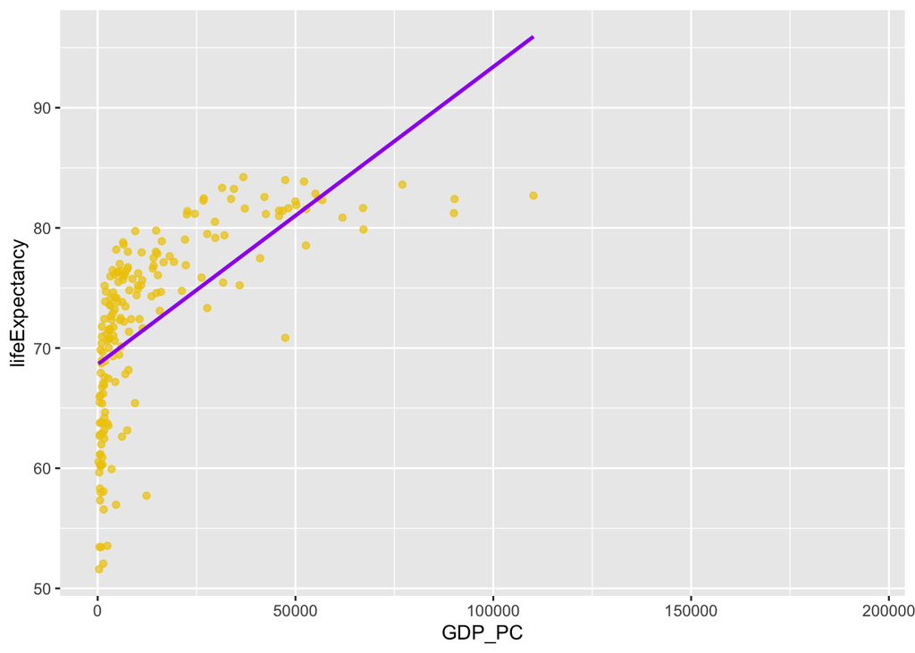

```r
gdp %>%
  ggplot(aes(GDP_PC, lifeExpectancy)) +
  geom_point(color = "gold2", alpha = 0.7) +
  geom_smooth(method = "lm", se = FALSE, color = "purple")
```

The relationship is not really linear.

```r
model2 <- lm(lifeExpectancy ~ log(GDP_PC/1000), data = gdp)
summary(model2)
```

```
##
## Call:
## lm(formula = lifeExpectancy ~ log(GDP_PC/1000), data = gdp)
##
## Residuals:
##      Min       1Q   Median       3Q      Max
## -17.7597  -2.2002   0.5273   3.0676   8.1841
##
## Coefficients:
##                  Estimate Std. Error t value Pr(>|t|)
## (Intercept)       64.5507     0.5154   125.2   <2e-16 ***
## log(GDP_PC/1000)   4.3439     0.2250    19.3   <2e-16 ***
## ---
## Signif. codes:  0 '***' 0.001 '**' 0.01 '*' 0.05 '.' 0.1 ' ' 1
##
## Residual standard error: 4.436 on 184 degrees of freedom
##   (31 observations deleted due to missingness)
## Multiple R-squared:  0.6694, Adjusted R-squared:  0.6676
## F-statistic: 372.6 on 1 and 184 DF,  p-value: < 2.2e-16
```

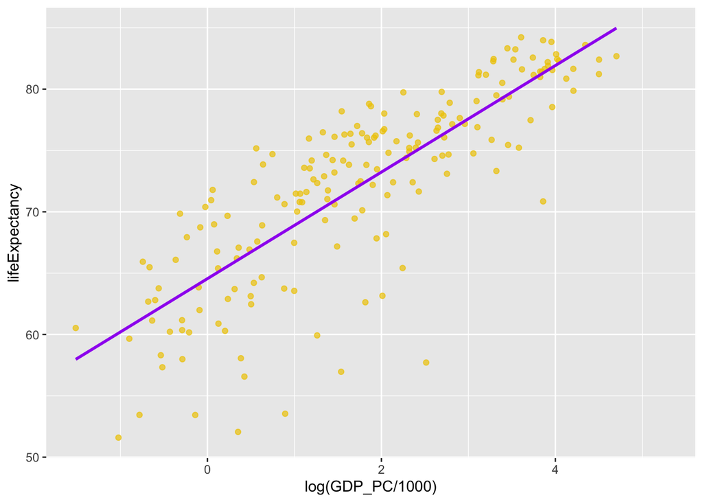

```r
gdp %>%
  ggplot(aes(log(GDP_PC/1000), lifeExpectancy)) +
  geom_point(color = "gold2", alpha = 0.7) +
  geom_smooth(method = "lm", se = FALSE, color = "purple")
```